# Homework 1.

## Базовые понятия для анализа временных рядов. Авторегрессионные модели.

1. (2 балла) Для чего нужно понятие стационарности в анализе временных рядов? Перечислите все случаи и распишите свой ответ.
2. (1 балл) Рассмотрите картинку data/images/ts_types.png.

a. Назовите ряды с гетероскедастичностью b. Какие ряды имеют сезонность? с. Какие ряды имеют цикличность? d. Какие ряды можно приблизить моделью интегрированного ряда? e. Какие ряды можно считать стационарными? 3. (3 балла) Рассмотрите один из графиков индекса Доу-Джонса (data/dataset/dow_jones.csv). Предположим, вы можете сделать только одно преобразование ряда, чтобы сделать его стационарным. Какое преобразование вы выберете и почему? Сделайте это преобразование, проверьте, получили ли вы стационарный ряд. Какой ARMA моделью можно описать получившийся стационарный ряд? 4. (2 балла) Рассмотрите ряд data/dataset/stl_example.csv. Постройте для него график автокорреляции.̆ Обьясните закономерности, которые вы видите. 5. (4 балла) На семинаре, посвященном stl разложению мы находили период сезонности сезонных временных рядов при помощи графика автокорреляций. Однако, если бы мы захотели построить автоматическую систему определения периода, мы бы уже не могли “вручную” анализировать каждый график. Таким образом вам необходимо написать функцию get_seasonal_period(), которая бы автоматически определяла период сезонных временных рядов, использую автокорреляционную функцию.  
6. (4 балла) Используя подход box-jenkins построит̆е модель ARIMA для временного ряда dow_jones_0. Сделайте прогноз на 30 точек вперед. Интерпретируйте полученный результат.

```python
import sys
from pathlib import Path

sys.path.append(str(Path().cwd()))
```

```python
import load_dataset
from plotting import plot_ts
import pandas as pd
import numpy as np
```

## 1. (2 балла) Для чего нужно понятие стационарности в анализе временных рядов? Перечислите все случаи и распишите свой ответ.\

Ответ: Стационарность предполагает постоянство мат ожидания, дисперсии, автокорреляции(зависимость только от лага) процесса. Такие процессы часто встречаются в реальной жизни, а для их описания существует много моделей.  
Например, можно считать станционарным рядом цену на актив в краткосрочном периоде, когда кажется логичным, что внешние условия не могут сильно измениться.

## 2. (1 балл) Рассмотрите картинку data/images/ts_types.png. \

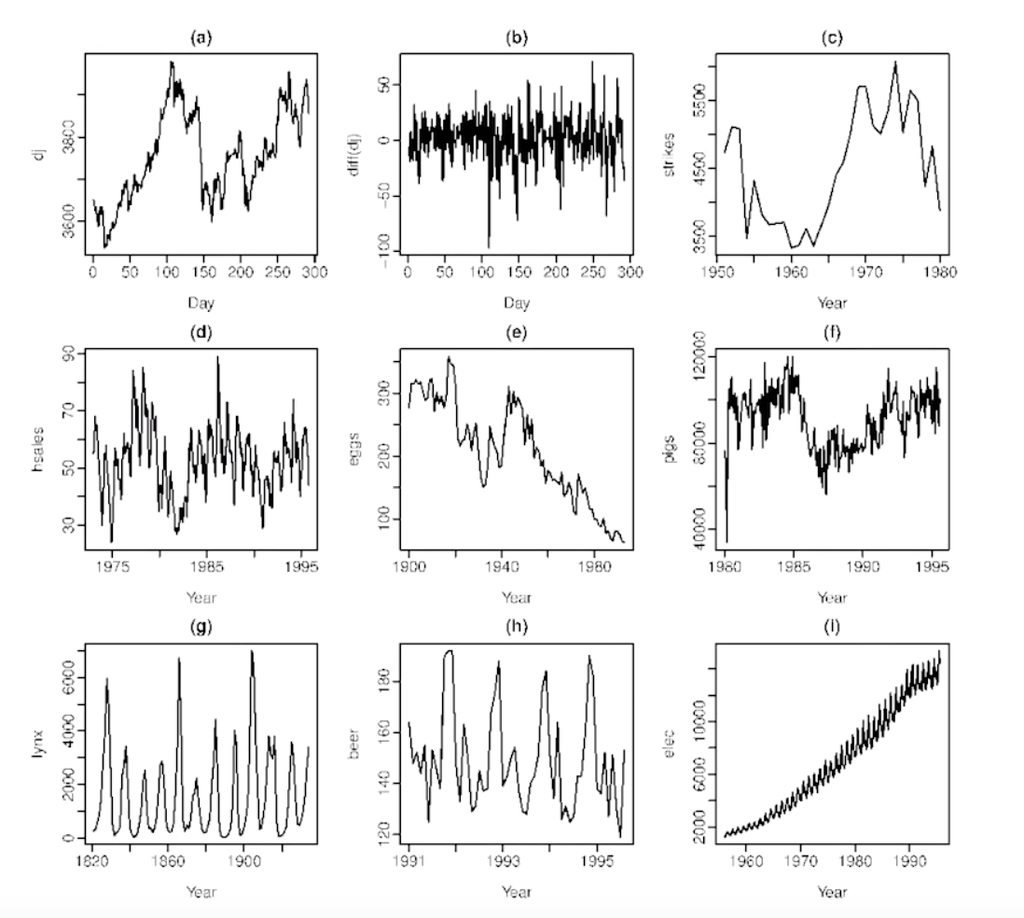

## 3. (3 балла) Рассмотрите один из графиков индекса Доу-Джонса (data/dataset/dow_jones.csv). Предположим, вы можете сделать только одно преобразование ряда, чтобы сделать его стационарным.

Какое преобразование вы выберете и почему? Сделайте это преобразование, проверьте, получили ли вы стационарный ряд. Какой ARMA моделью можно описать получившийся стационарный ряд?

```python
dataset = load_dataset.Dataset('data/dataset/')
```

```python
ts = dataset['dow_jones_1.csv']
```

```python
plot_ts(ts)
```

[interactive chart not shown]

Видно, что не выделить сезонность, а ткаже то, что скачки между точками по модулю примерно одинаковые. Можно сделать дифференцирование с лагом 1.

```python
plot_ts(ts.diff())
```

[interactive chart not shown]

## 4. (2 балла) Рассмотрите ряд data/dataset/stl_example.csv. Постройте для него график автокорреляции.̆ Обьясните закономерности, которые вы видите.

```python
from statsmodels.graphics.tsaplots import plot_acf, plot_pacf
from statsmodels.tsa.stattools import pacf
```

```python
ts = dataset['stl_example.csv']
```

```python
plot_ts(ts);
```

[interactive chart not shown]

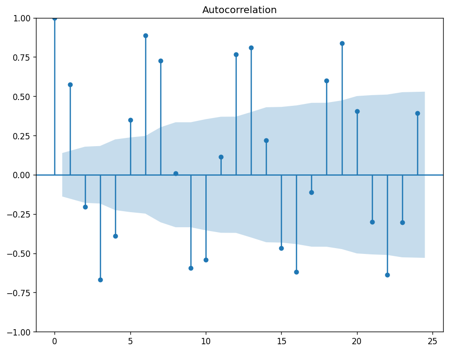

```python
plot_acf(ts);
```

Корреляция с лагом 1: две соседние точки часто имеют один знак отклонения от среднего всего процесса.  
Корреляция с лагом 6: сезонность.  
Корреляция с лагом 7: т.к. 6й и 7й лаг скоррелированы

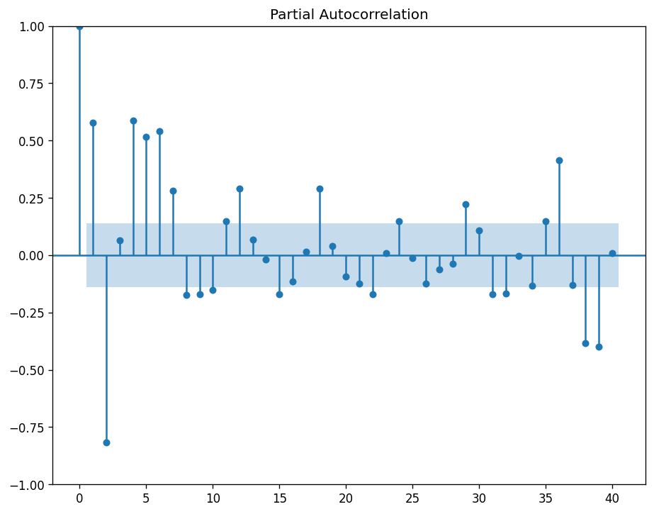

```python
plot_pacf(ts, lags=40);
```

Сильная отрицательная корреляция с лагом 2: даже если вычесть влияние точек между двумя точками с лагом 2, то корреляция все равно остается сильной. Видимо изначально в процессе(теоретически, если выражать в формуле), $y_t = \theta * y_{t-2} + res$, где $\theta$ отрицательная, причем ближе к $-1$, чем к $0$, а $res$ - какая-то зависимость от всего остального.  
Получается, сильная отрицательная корреляция с лагом 3, которая видна на графике ACF, обусловлена "настоящей" корреляцией с лагом 2, а точка с 3 лагом просто близка по времени к точке с лагом 2.  
Сильная корреляция с лагами 5,6,7: какое-то из этих чисел - сезоность.

## 5. (4 балла) На семинаре, посвященном stl разложению мы находили период сезонности сезонных временных рядов при помощи графика автокорреляций.

```
Однако, если бы мы захотели построить автоматическую систему определения периода, мы бы уже не могли “вручную” анализировать каждый график.
Таким образом вам необходимо написать функцию get_seasonal_period(), которая бы автоматически определяла период сезонных временных рядов, использую автокорреляционную функцию.
```

```python
def extract_trend(ts: pd.Series):
    """
    Извлекает линейный тренд из временного ряда (из семинара stl)
    """
    x = np.arange(len(ts))
    k, b = np.linalg.lstsq(np.vstack([x, np.ones(len(x))]).T, ts.values, rcond=None)[0]
    trend = k * x + b
    return pd.Series(trend, index = ts.index), k, b
```

```python
from statsmodels.tsa.stattools import acf
```

```python
def get_seasonal_period(ts):
    detrended = ts - extract_trend(ts)[0] # избавляемся от тренда
    acf_values = acf(detrended, nlags = int(len(detrended)/2)) # автокорреляция
    acf_val = pd.Series(acf_values)
    candidates = acf_val.sort_values(ascending = False)[:10] # берем 10 точек с max значениями
    conf = {x : 0 for x in candidates.sort_index().index[1:]}
    # находим индексы, которые кратно повторяются в топ 10 (например, 6, 12, 18)
    for idx in conf.copy().keys():
        for k in range(2, int(len(detrended)/(2*idx))):
            if idx*k in conf.keys():
                conf.pop(idx*k)
                conf[idx] += 1
    # берем минимальный из тех, которые повторяются чаще всех
    result = max(conf, key = conf.get)
    return result
```

```python
get_seasonal_period(ts)
```

```
6
```

```python
plot_ts(ts)
```

[interactive chart not shown]

```python
ts1 = dataset["alcohol_sales.csv"]
```

```python
get_seasonal_period(ts1)
```

```
12
```

```python
plot_ts(ts1)
```

[interactive chart not shown]

ниже пометки для себя

```python
#при мальеньких значениях x совпадает, а при больших - нет
# x = 40
#acf_values = acf(detrended, nlags = int(len(detrended)/2))
# acf_values[x]
# np.corrcoef(detrended.shift(x)[x:].values, detrended[x:].values)
# в последнем случае не затухает корреляция
```

```python
# lags = int(len(detrended)/2)
# df = pd.concat([detrended.shift(i) for i in range(lags,-1,-1)], axis = 1)
# df.columns = ['t'+ str(i) for i in range(lags,-1,-1)]
# corr = df.corr() #- так коррелограмма не затугахет на больших лагах, в statmodels есть еще зависимость от количества точек, на которых корреляция считается?
```

## 6. (4 балла) Используя подход box-jenkins построит̆е модель ARIMA для временного ряда dow_jones_0. Сделайте прогноз на 30 точек вперед. Интерпретируйте полученный результат.

```python
ts = dataset["dow_jones_0.csv"]
```

Посмотрим ряды с разным лагом

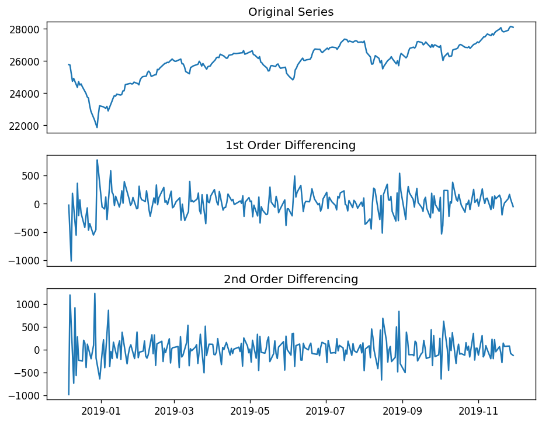

```python
import matplotlib.pyplot as plt
plt.rcParams.update({'figure.figsize':(9,7), 'figure.dpi':120})
fig, (ax1, ax2, ax3) = plt.subplots(3)
ax1.plot(ts); ax1.set_title('Original Series'); ax1.axes.xaxis.set_visible(False)
# 1st Differencing
ax2.plot(ts.diff()); ax2.set_title('1st Order Differencing'); ax2.axes.xaxis.set_visible(False)
# 2nd Differencing
ax3.plot(ts.diff().diff()); ax3.set_title('2nd Order Differencing')
plt.show()
```

Автокорреляция

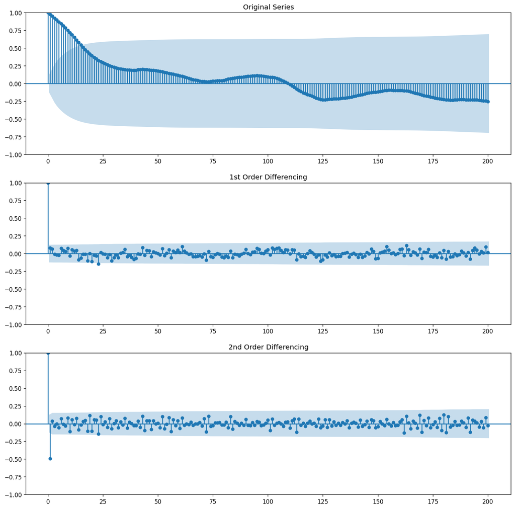

```python
fig, (ax1, ax2, ax3) = plt.subplots(3, figsize = (15,15))
plot_acf(ts, ax=ax1, lags = 200); ax1.set_title('Original Series')
plot_acf(ts.diff().dropna(), ax=ax2, lags = 200);ax2.set_title('1st Order Differencing')
plot_acf(ts.diff().diff().dropna(), ax=ax3, lags = 200);ax3.set_title('2nd Order Differencing')
```

Частичная автокорреляция

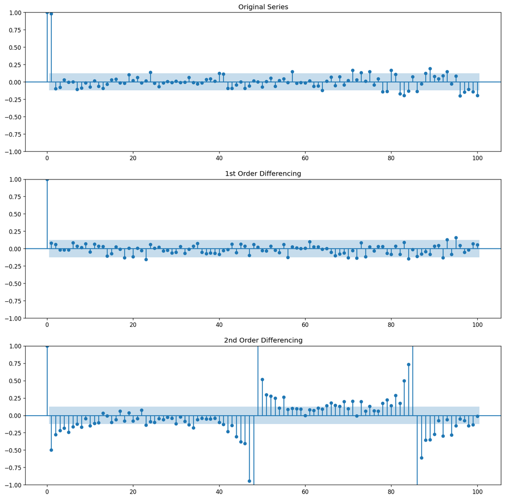

```python
fig, (ax1, ax2, ax3) = plt.subplots(3, figsize = (15,15))
plot_pacf(ts, ax=ax1, lags = 100); ax1.set_title('Original Series')
plot_pacf(ts.diff().dropna(), ax=ax2, lags = 100);ax2.set_title('1st Order Differencing')
plot_pacf(ts.diff().diff().dropna(), ax=ax3, lags = 100);ax3.set_title('2nd Order Differencing')
```

Непонятные всплески на 49м лаге при 2x дифференцировании. Но зато есть резкое затухание ACF после 1 лага, значит, метод box-jenkins подходит.  
В случае с 1x дифференцированием ряд становится похож просто на белый шум.

```python
from statsmodels.tsa.stattools import adfuller
```

```python
adfuller(ts.diff(1).diff(1).dropna())[1]
```

```
4.6858578523147043e-17
```

p-value очень маленькое, значит нулевая гипотеза о нестационарности ряда отвергается.

```python
ts_flat = ts.diff(1).diff(1).dropna()
```

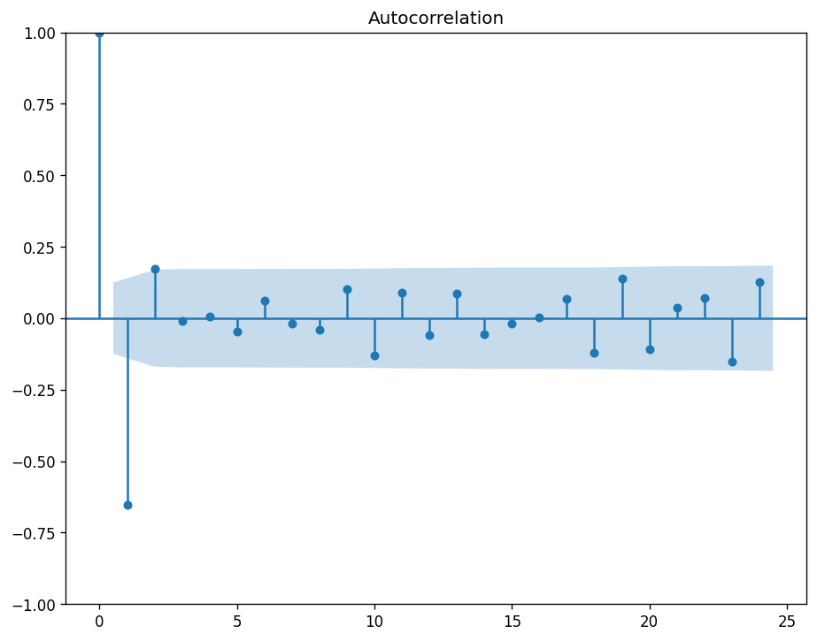

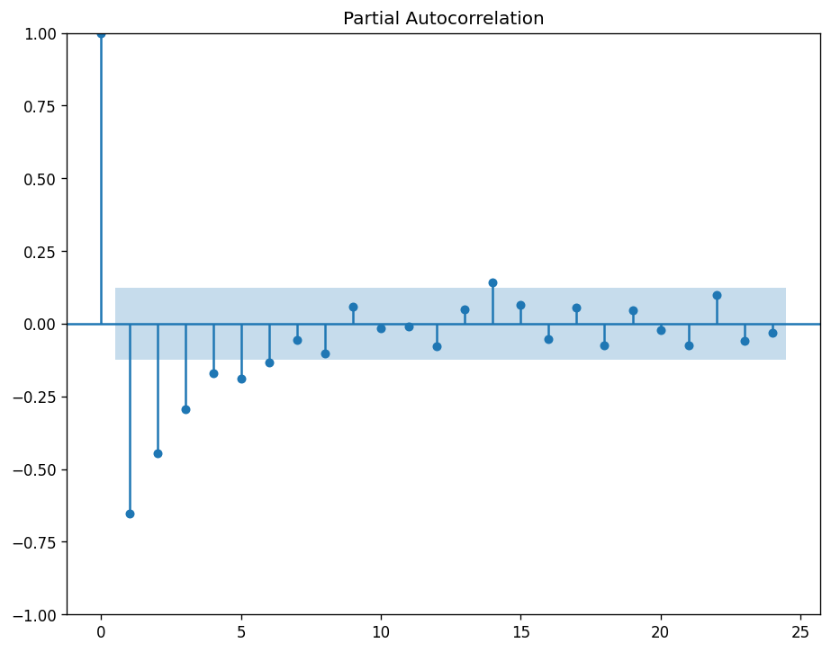

```python
plot_acf(ts_flat.diff().dropna());
plot_pacf(ts_flat.diff().dropna());
```

```python
from statsmodels.tsa.arima.model import ARIMA
```

```python
model = sm.tsa.arima.ARIMA(ts, order = (0,2,1))
model_fit = model.fit()
```

```python
preds = model_fit.forecast(30)
```

```python
import datetime
```

```python
base = datetime.datetime(2019,11,29)
date_list = [base + datetime.timedelta(days=x) for x in range(1,31)]
```

```python
preds.index = date_list
```

```python
plot_ts(ts, preds)
```

[interactive chart not shown]

Модель выучила тренд и даже не попыталась подстроиться под маленькие колебания